# Quickstart Guide to ggseqalign

Simeon Lim Rossmann

Norwegian University of Life Sciences (NMBU)

simeon.rossmann@nmbu.no

21 May 2024

#### Abstract

Provides basic instructions to create minimal visualizations of pairwise alignments from various inputs.

#### Package

ggseqalign 0.2.0

# Contents

[figure not shown]

# 1 Introduction

Showing small differences between two long strings, such as DNA or AA sequences is challenging, especially in R. Typically, DNA or AA sequence alignments show all characters in a sequence. The package *ggmsa* does this really well and is compatible with ggplot2. However, this is not viable for sequences over a certain length. Alternatively, top level visualizations may, for example, represent degree of variation over the length in a line plot, making it possible to gauge how strongly sequences differ, but not the quality of the difference. The intention with this package is to provide a way to visualize sequence alignments over the whole length of arbitrarily long sequences without losing the ability to show small differences, see figure 1.

[figure not shown]

Figure 1: Example of ggseqalign visualization  
Showcase of the package’s capability to highlight differences between 2000 bp long DNA sequences.

# 2 Installation

`ggseqalign` can be installed from it’s original source on GitLab (requires `devtools`)

```r
devtools::install_git("https://gitlab.com/nmbu.no/ipv/lim-rossmann/ggseqalign.git")
```

This will be updated for installation instructions from Bioconductor if the submission is successful.

# 3 Basics

This package relies on two core functions, `alignment_table()` and `plot_sequence_alignment()`. At its core, the former uses `PairwiseAlignment()`, previously in *Biostrings*, now in *pwalign*, to align one or several query strings to a subject string to parse all information on mismatches, insertions and deletions into a table that is used as the input for plotting with `plot_sequence_alignment()`.

A minimal example:

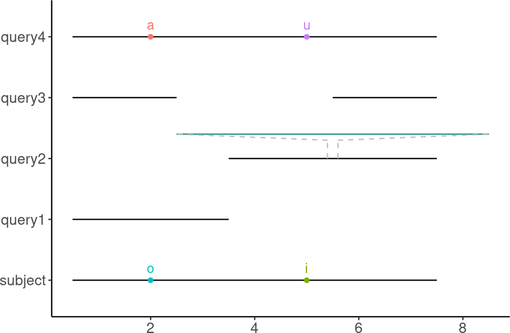

Figure 2: Output of the minimal example code

```r
library(ggseqalign)

query_strings <- (c("boo", "fibububuzz", "bozz", "baofuzz"))
subject_string <- "boofizz"

alignment <- alignment_table(query_strings, subject_string)

plot_sequence_alignment(alignment) +
  theme(text = element_text(size = 15))
```

To align DNA or AA sequences from a fasta file, read them in with `readDNAStringSet()` from *Biostrings*.

```r
library(ggseqalign)
library(Biostrings)

query_sequences <- Biostrings::readDNAStringSet("my_multi_sequence_fasta.fa")
subject_sequence <- Biostrings::readDNAStringSet("my_reference_fasta.fa")

alignment <- alignment_table(query_sequences, subject_sequence)

plot_sequence_alignment(alignment) +
  theme(text = element_text(size = 15))
```

# 4 Hide mismatches

The plots that `plot_sequence_alignment()` generates can become hard to read if there are too many differences, see fig. 3. The package allows to hide character mismatches to preserve legibility of structural differences (fig. 4). The example below uses example data from the Biostrings package.

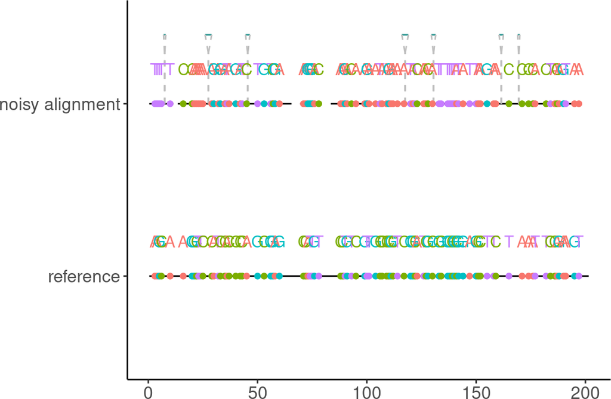

Figure 3: Example of a case where ggseqalign fails  
If there are too many differences, the mismatches overlap each other and become noisy.

```r
# load
dna <- Biostrings::readDNAStringSet(system.file("extdata", "dm3_upstream2000.fa.gz",
                                     package="Biostrings"))
q <- as(c(substr(dna[[1]], 100, 300)),
            "DNAStringSet")
s <- as(c(substr(dna[[2]], 100, 300)),
            "DNAStringSet")
names(q) <- c("noisy alignment")
names(s) <- "reference"

plot_sequence_alignment(alignment_table(q, s)) +
  theme(text = element_text(size = 15))
```

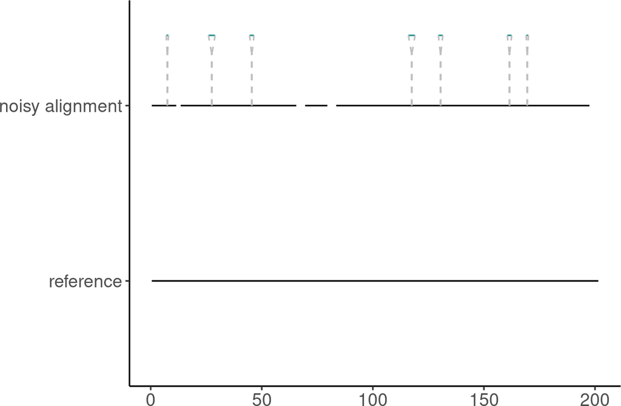

Figure 4: Hiding mismatches  
Hiding character mismatches reduces visual noise if alignments have many character mismatches and preserves structural information.

```r
plot_sequence_alignment(alignment_table(q, s), hide_mismatches = TRUE) +
  theme(text = element_text(size = 15))
```

# 5 Styling with ggplot2

Since `plot_sequence_alignment()` produces a ggplot-class object, all aspects of the plots can be modified with *ggplot2* functions, such as `theme()`. As an example, let’s modify figure 1.

[figure not shown]

Figure 5: Styling with ggplot2  
In this example, text size was increased, axis labels were added, x-axis text rotated and the color scheme changed.

```r
library(ggseqalign)
library(ggplot2)
library(Biostrings)

dna <- readDNAStringSet(system.file("extdata", "dm3_upstream2000.fa.gz",
                                     package="Biostrings"))

q <- dna[2:4]
s <- dna[5]

q[1] <- as(replaceLetterAt(q[[1]], c(5, 200, 400), "AGC"),
             "DNAStringSet")
q[2] <- as(c(substr(q[[2]], 300, 1500), substr(q[[2]], 1800, 2000)),
            "DNAStringSet")
q[3] <- as(replaceAt(q[[3]], 1500,
              paste(rep("A", 1000), collapse = "")),
            "DNAStringSet")
names(q) <- c("mismatches", "deletions", "insertion")
names(s) <- "reference"

pl <- plot_sequence_alignment(alignment_table(q, s))

pl <- pl +
 ylab("Sequence variants") +
 xlab("Length in bp") +
 scale_color_viridis_d() +
 theme(text = element_text(size = 20),
       axis.text.x = element_text(angle = 90, vjust = 0.5, hjust = 1),
    axis.title = element_text())

pl
```

Some modifications may require digging into the plot object layers, this can get finicky but is possible. We can use `pl$layers` to get a summary of the object’s layers. In this case, the geom_point layers that plot the dots for mismatches are entry 8 in the layer list, the white bar that indicates deletions is usually in layer 2. You may want to change the deletion bar’s color if you use another plot background color.

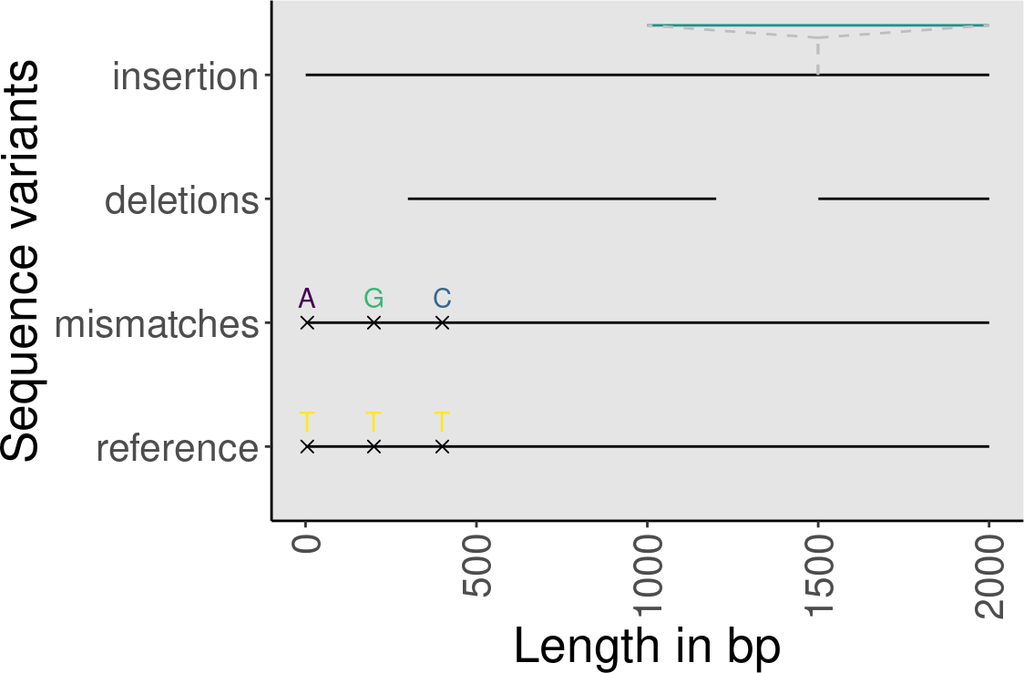

Figure 6: Modifying ggplot2 layers  
In this example, deletion bars were adjusted to match background color and mismatch indicators were modified using plot layer modification

```r
# Define background color
bg <- "grey90"

# Change plot background
pl <- pl + theme(panel.background = element_rect(fill = bg,
                                colour = bg))

# Match deletion to background
pl$layers[[2]]$aes_params$colour <- bg
# Increase mismatch indicator size and change shape
pl$layers[[8]]$aes_params$size <- 2
pl$layers[[8]]$aes_params$shape <- 4
pl$layers[[8]]$aes_params$colour <- "black"

pl
```